# Broeder Experiment 1

### Some info on the models

**Model 1:** r_1 = r_8 (highest confidence response mapping of detection states equated)  
**Model 2:** q_4 = q_5 (lowest confidence response mapping of uncertainty states equated)  
**Model 3:** r_1 = r_8 & q_4 = q_5 (highest confidence response mapping of detection states equated and lowest confidence response mapping of uncertainty states equated)  
**Model Original:** q_2 = q_7, q_3 = q_6 & r_3 = r_6 (lowest and intermediate confidence response mapping of uncertainty states equated and lowest confidence response mapping of detection states equated)

### Some info on convergence

#### For Model 1

Two approaches failed:  
partial, TreeBUGS, trait  
partial, TreeBUGS, beta

Frequentist approach with complete pooling had no convergence problems (asymptotic.complete.MPTinR).

Bayesian approach with complete pooling Rhat < 1.05, therefore converged well (simple.complete.TreeBUGS).  
Bayesian approach with no pooling (simple.no.TreeBUGS) had 374 parameters with Rhat > 1.05.  
Bayesian approach with partial pooling (trait_uncorrelated.partial.TreeBUGS) had 58 parameters with Rhat > 1.05.

#### For Model 2

One approach failed:  
partial, TreeBUGS, beta

Frequentist approach with complete pooling (asymptotic.complete.MPTinR) had some convergence problems:  
condition rank.fisher n.parameters convergence  
1 aggregated 6 14 0  
2 strong_naming 6 14 0  
3 weak_naming 9 14 0

Bayesian approach with no pooling (simple.no.TreeBUGS) had 7 parameters with Rhat > 1.05.  
Bayesian approach with complete pooling (simple.complete.TreeBUGS) converged well, all Rhat < 1.05.  
Bayesian approach with partial pooling (trait) had 38 parameters with Rhat > 1.05, but uncorrelated (trait_uncorrelated.partial.TreeBUGS) converged well with all Rhat < 1.05.

#### For Model 3

One approach failed:  
partial, TreeBUGS, beta

Frequentist approach with complete pooling had no convergence problems (asymptotic.complete.MPTinR).

Bayesian approach with no pooling (simple.no.TreeBUGS) had 204 parameters with Rhat > 1.05.  
Bayesian approach with complete pooling (simple.complete.TreeBUGS) converged well, all Rhat < 1.05.  
Bayesian approach with partial pooling (trait) had 259 parameters with Rhat > 1.05, but uncorrelated (trait_uncorrelated.partial.TreeBUGS) had one parameter with Rhat > 1.05.

#### For Model Original

Two approaches failed:  
partial, TreeBUGS, trait  
partial, TreeBUGS, beta

Frequentist approach with complete pooling had no convergence problems (asymptotic.complete.MPTinR).

Bayesian approach with no pooling (simple.no.TreeBUGS) had 3 parameters with Rhat > 1.05.  
Bayesian approach with complete pooling (simple.complete.TreeBUGS) converged well, all Rhat < 1.05.  
Bayesian approach with partial pooling (trait_uncorrelated.partial.TreeBUGS) converged well, all Rhat < 1.05.

### Parameter estimation

**Model 1**

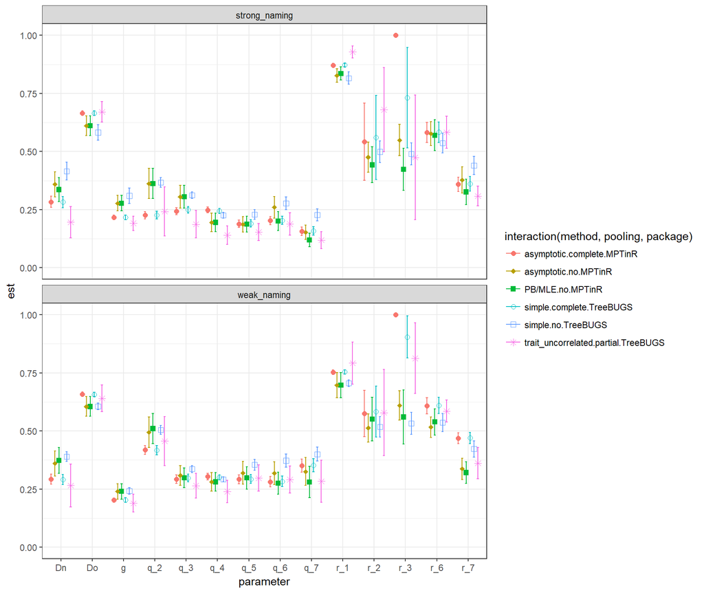

**Model 2**

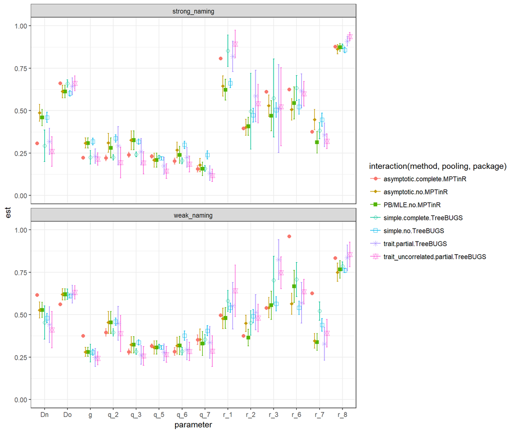

**Model 3**

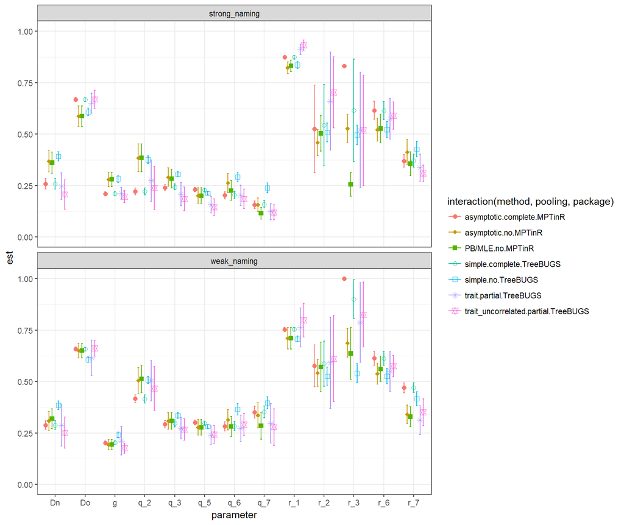

**Model Original**

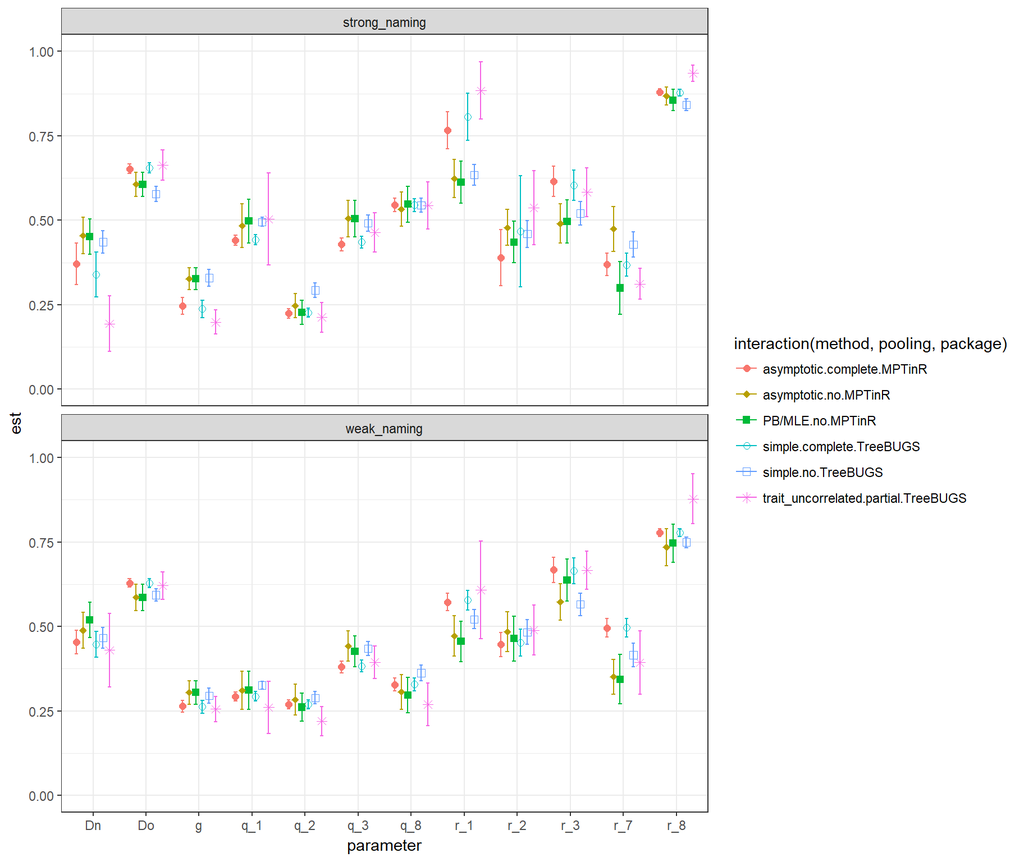

### Estimated differences

**Model 1**

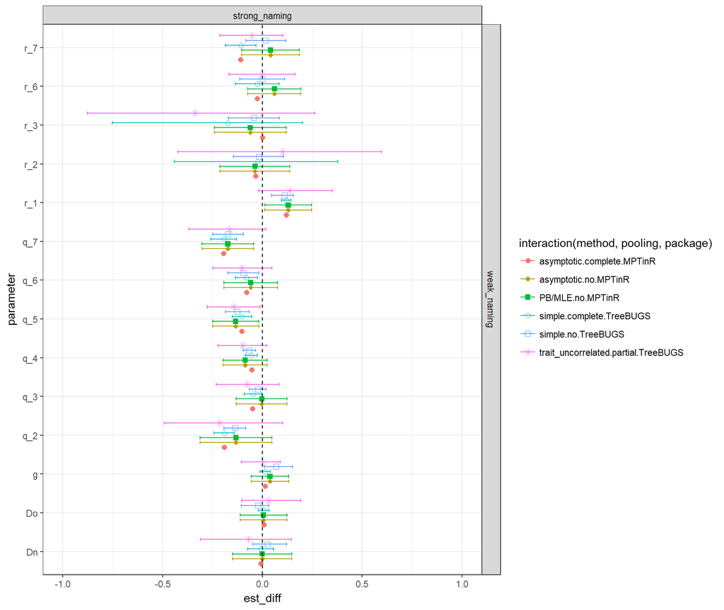

**Model 2**

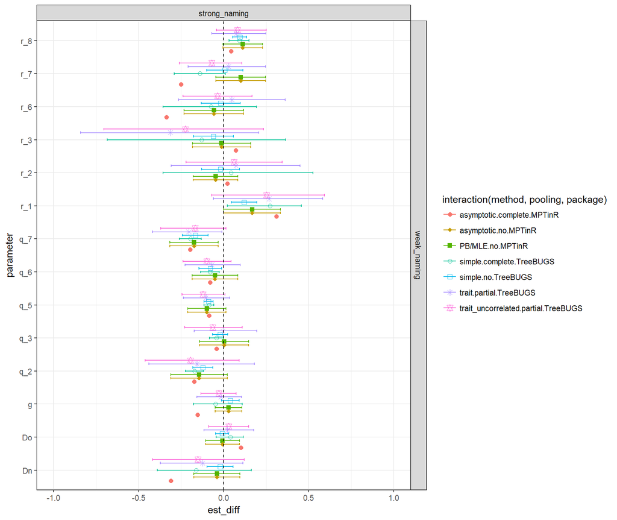

**Model 3**

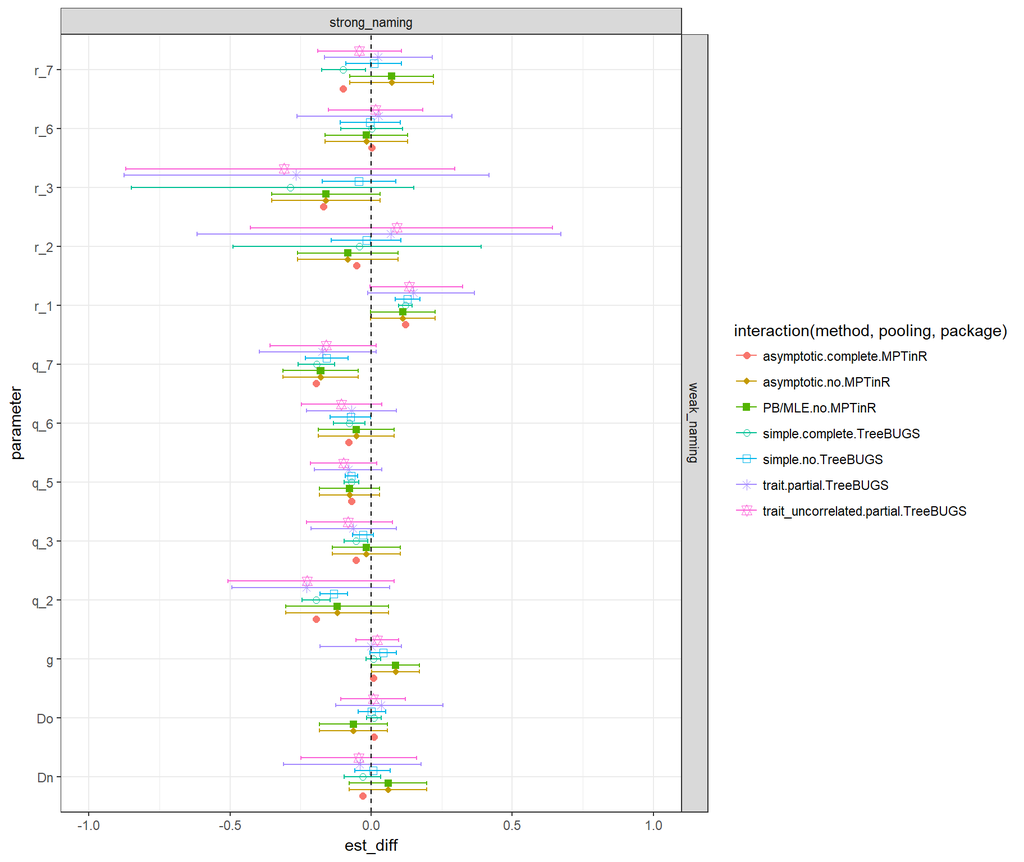

**Model Original**

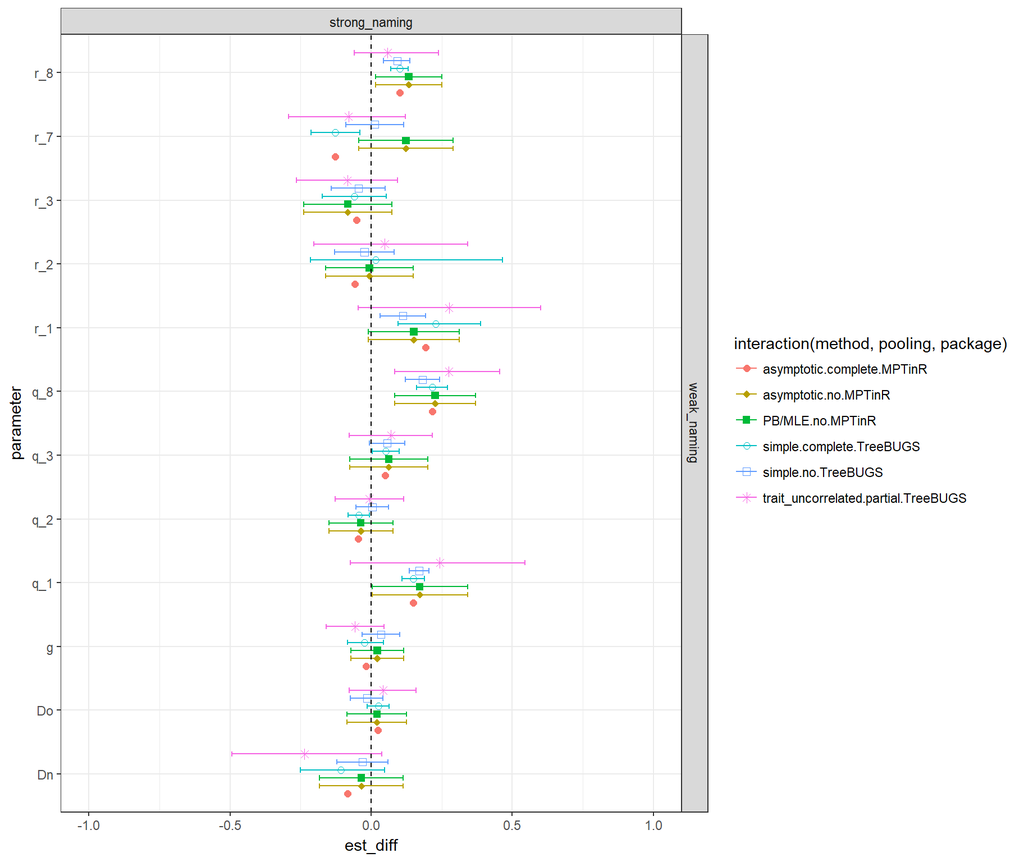

### Goodness of fit

**Model 1**

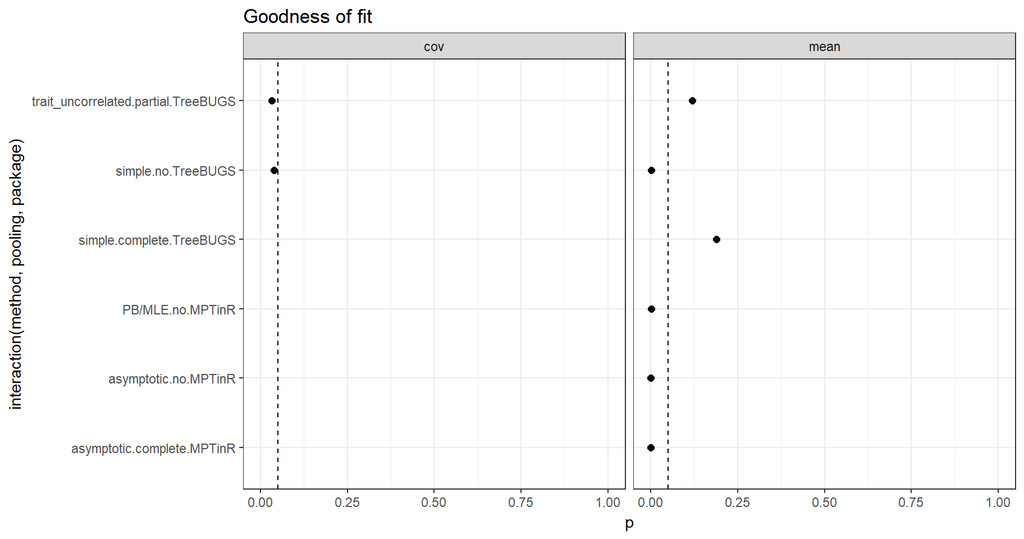

**Model 2**

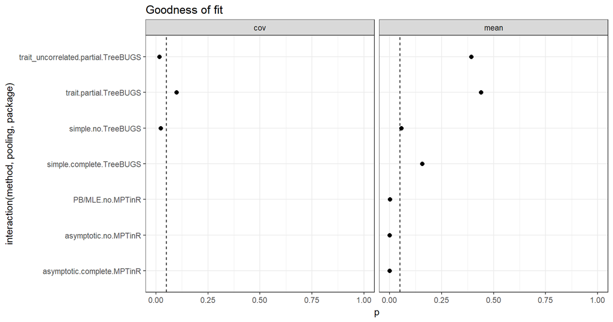

**Model 3**

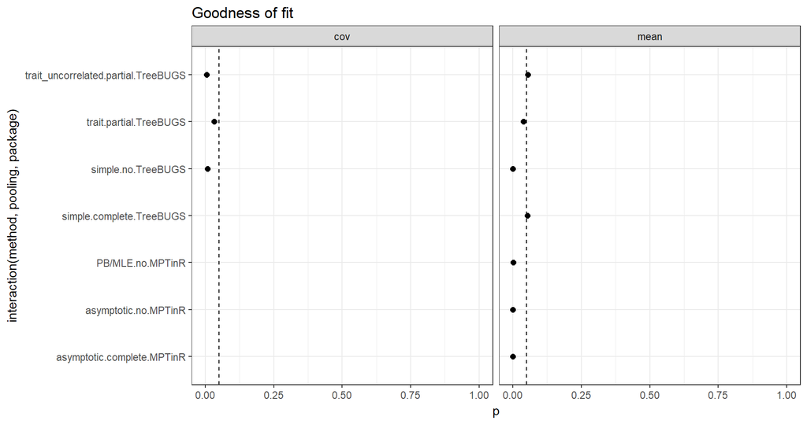

**Model Original**

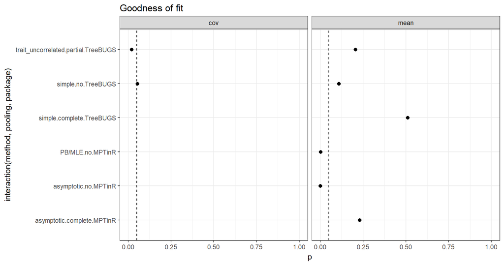

### Goodness of fit per condition

**Model 1**

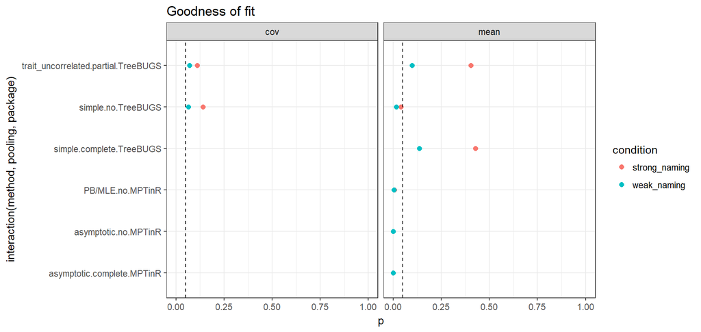

**Model 2**

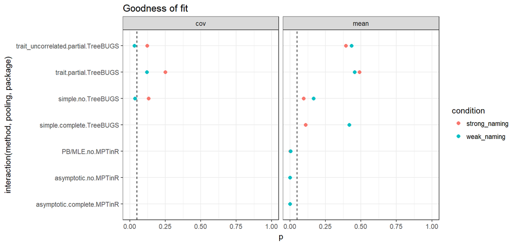

**Model 3**

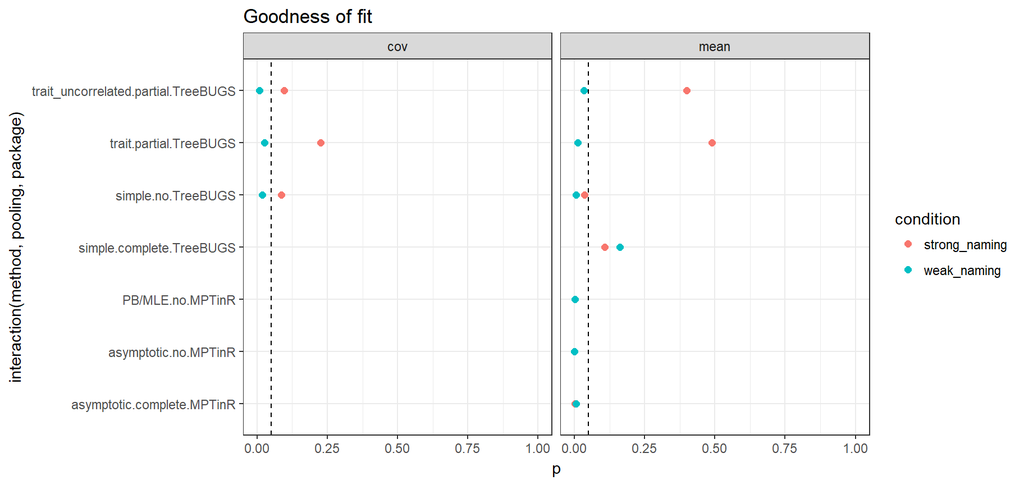

**Model Original**

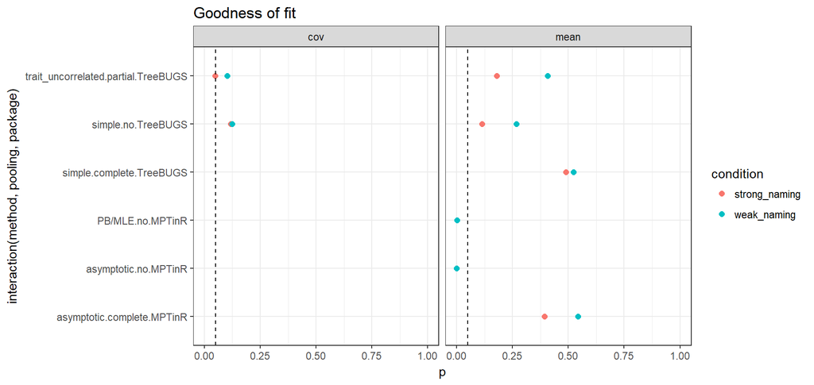